# RaMWAS QC Measures

Andrey A Shabalin

2016-10-25

# 1 Loading and Saving RaMWAS objects

All RaMWAS objects are saved as text files, filematrices, or .rds files. The .rds files are operated with `saveRDS` and `readRDS` functions.

Below we load a sample QC file, which contains accumulated QC measures from BAM files of a small project.

```r
filename = system.file("extdata", "bigQC.rds", package = "ramwas");
qc = readRDS(filename)$qc;
# show(names(qc))
```

# 2 Quality control measures

All QC measures are designed to be additive, in the sence that any QC measure calculated for a concatination of two BAM files is equal to the sum of the respective measure calculated for those BAMs separately.

Many QC measures can be visualized by calling `plot` function on them. For some, single number summary is available via `qcmean` function.

The currently supported QC measures include the following:

## 2.1 The number of BAM files

There sample QC file accumulates information from 42 BAMs.

```r
cat("N BAMs:", qc$nbams)
```

```
## N BAMs: 42
```

## 2.2 Total number of reads in the BAM file(s)

The 42 BAMs contain 2.46 billion reads.

```r
cat("Reads total:", qc$reads.total)
```

```
## Reads total: 2464441416
```

## 2.3 Number of reads aligned to the reference genome

The number of aligned reads is only 2% smaller, 2.42 billion.

```r
{
 cat("Reads aligned:", qc$reads.aligned, "\n")
 cat("This is ", qc$reads.aligned / qc$reads.total * 100, "% of all reads", sep="")
}
```

```
## Reads aligned: 2422356052
## This is 98.2923% of all reads
```

## 2.4 Number of reads that passed minimum score filter and are recorded

Almost of 2.2 billion reads passed the score threshold.

```r
{
 cat("Reads recorded:",qc$reads.recorded,"\n")
 cat("This is ", qc$reads.recorded / qc$reads.aligned * 100, "% of aligned reads", sep="")
}
```

```
## Reads recorded: 2197642600
## This is 90.72335% of aligned reads
```

## 2.5 Number of recorded reads aligned to the forward and reverse strands respectively

For this measure, `qcmean` returns the fraction of reads on forward strand. Normally, the number of reads on forward and reverse strands is very close, so `qcmean` should give a number close to `0.5`.

```r
{
 cat("Reads on forward strand:", qc$frwrev[1],"\n")
 cat("Reads on reverse strand:", qc$frwrev[2],"\n")
 cat("Fraction of reads on forward strand:", qcmean(qc$frwrev), "\n")
}
```

```
## Reads on forward strand: 1098313225
## Reads on reverse strand: 1099329375
## Fraction of reads on forward strand: 0.4997688
```

## 2.6 Distribution of the read scores

The QC measures `bf.hist.score1` and `hist.score1` record the distribution of the alignment scores before and after the filter. The score is defined by the `scoretag` parameter. While `hist.score1` contain the distribution for reads that passed the filter, `bf.hist.score1` has the distribution for all reads. The `qcmean` function for this QC measure returns the average score for the respective group. The first element of the vector `qc$hist.score1` contains the number of reads with score of 0, the second with score of 1, and so on. Negative scores (if any) are ignored.

```
## Average alignment score: 144.1565
## Average alignment score, no filter: 137.8565
```

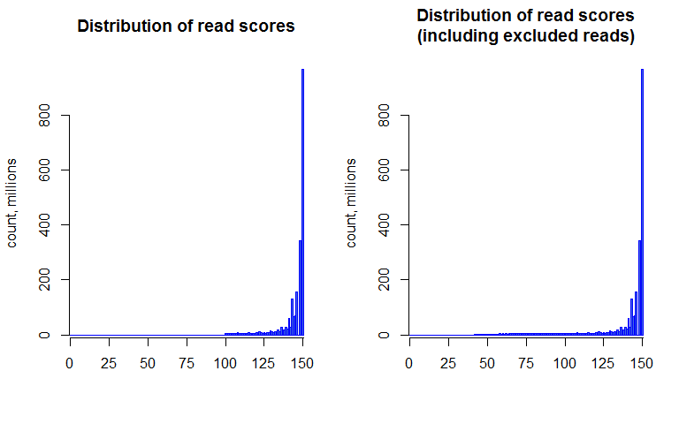

```r
{
 cat("Average alignment score:", qcmean(qc$hist.score1), "\n")
 cat("Average alignment score, no filter:", qcmean(qc$bf.hist.score1), "\n")
 par(mfrow=c(1,2))
 plot(qc$hist.score1)
 plot(qc$bf.hist.score1)
}
```

## 2.7 Distribution of the length of the aligned part of the reads

The length of the aligned part of a read is calculated from the CIGAR string in the BAM file using `cigarWidthAlongQuerySpace` function. As previously, `hist.length.matched` has the distribution for reads that passed the filter, `bf.hist.length.matched` - for all reads. The `qcmean` function for this QC measure returns the average value for the respective group. The first element of the vector contains the number of reads with 1 aligned basepair, the second with 2, and so on.

```
## Average aligned length: 74.22412
## Average aligned length, no filter: 72.60318
```

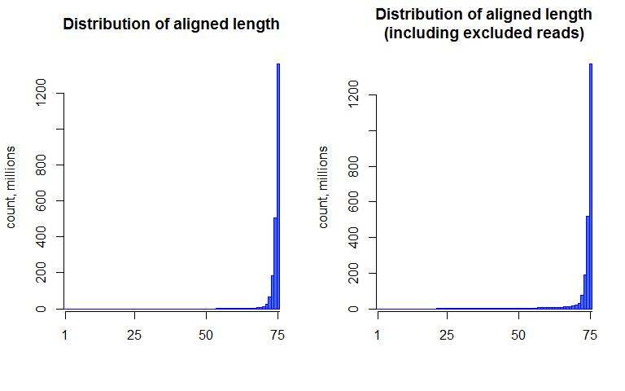

```r
{
 cat("Average aligned length:", qcmean(qc$hist.length.matched), "\n")
 cat("Average aligned length, no filter:", qcmean(qc$bf.hist.length.matched), "\n")
 par(mfrow = c(1,2))
 plot(qc$hist.length.matched)
 plot(qc$bf.hist.length.matched)
}
```

## 2.8 Distribution of edit distance between the aligned part of the read and the reference genome

This QC measure is recorded from NM tag in BAM files. As previously, `hist.edit.dist1` has the distribution for reads that passed the filter, `bf.hist.edit.dist1` - for all reads. The `qcmean` function for this QC measure returns the average value for the respective group. The first element of the vector contains the number of reads with 0 edit distance (perfect match), the second with edit distance 1, and so on.

```
## Average edit distance: 0.7361304
## Average edit distance, no filter: 1.220491
```

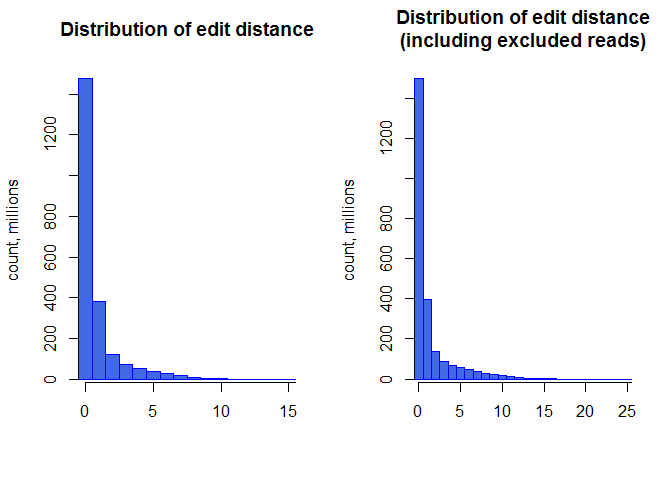

```r
{
 cat("Average edit distance:", qcmean(qc$hist.edit.dist1), "\n")
 cat("Average edit distance, no filter:", qcmean(qc$bf.hist.edit.dist1), "\n")
 par(mfrow = c(1,2))
 plot(qc$hist.edit.dist1)
 plot(qc$bf.hist.edit.dist1)
}
```

## 2.9 Number of reads after removal of duplicate reads

When there are mulptiple reads with the same start position, we suspect them to be falsely duplicated. In this case, reads in excess of 3 are removed (3 set by parameter). Item `reads.recorded.no.repeats` records the total number of reads after removal of duplicates and `frwrev.no.repeats` show split between the forward and reverse strands. In our example, after removal of duplicates we are left with 90% of the reads. After removal of duplicate reads the fraction of reads on forward strand got even closer to 0.5.

```r
{
 cat("Reads without duplicates:", qc$reads.recorded.no.repeats, "\n")
 cat("This is ", qc$reads.recorded.no.repeats / qc$reads.recorded * 100, "% of aligned reads", "\n", sep="")
 cat("Fraction of reads on forward strand (with    duplicates):", qcmean(qc$frwrev), "\n")
 cat("Fraction of reads on forward strand (without duplicates):", qcmean(qc$frwrev.no.repeats), "\n")
}
```

```
## Reads without duplicates: 1987137468
## This is 90.42132% of aligned reads
## Fraction of reads on forward strand (with    duplicates): 0.4997688
## Fraction of reads on forward strand (without duplicates): 0.4999143
```

## 2.10 Number of reads away from CpGs

Reads starting at least away from any CpG is likely to be part of noise, not signal. High fraction of such reads usually indicate high noise levels and poor sample quality. The QC measure `cnt.nonCpG.reads` contains the number of non-CpG reads in it“s first element.

Is our example the are less than 1% of non-CpG reads, which is consistent with low level of noise.

```r
{
 cat("Non-CpG reads:", qc$cnt.nonCpG.reads[1], "\n")
 cat("This is ", qcmean(qc$cnt.nonCpG.reads)*100, "% of recorded reads", sep="")
}
```

```
## Non-CpG reads: 10764340
## This is 0.5669618% of recorded reads
```

## 2.11 Average coverage of CpGs and non-CpGs

Another measure of success of enrichment is calculated as follows. We calculate average coverage of all CpGs and the average coverage at a set of locations away from CpGs (so-called non-CpGs). The ratio gives us a lower bound on the enrichment level of the samples.

```r
{
 cat("Summed across", qc$nbams, "bams", "\n")
 cat("Average     CpG coverage:", qc$avg.cpg.coverage,   "\n")
 cat("Average non-CpG coverage:", qc$avg.noncpg.coverage,"\n")
 cat("Enrichment ratio:", qc$avg.cpg.coverage / qc$avg.noncpg.coverage)
}
```

```
## Summed across 42 bams
## Average     CpG coverage: 255.8143
## Average non-CpG coverage: 1.766378
## Enrichment ratio: 144.8242
```

## 2.12 Coverage around isolated CpGs

Isolated CpGs have weak ability for enrichment. Nontheless, we expect there to be more read start sites closer to isolated CpGs, rather than couple hundred basepairs away. The QC measure `hist.isolated.dist1` records the distribution of distances from read start sites to isolated CpGs. In our example, as we expected, there are more reads starting closer to isolated CpGs.

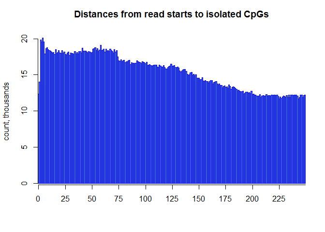

```r
plot(qc$hist.isolated.dist1)
```

## 2.13 Fraction of reads from chrX and chrY

The fractions of reads from chrX and chrY can be used to test whether the individuals have the same genetic gender as recorded in the records. Mismatches often indicate swapped or mislabeled samples. The first element of `qc$chrX.count` contains the number of chrX reads, while `qcmean(qc$chrX.count)` gives the fraction of total. Same for chrY.

```r
{
 cat("ChrX reads: ", qc$chrX.count[1], ", which is ", qcmean(qc$chrX.count)*100, "% of total", sep="", "\n")
 cat("ChrX reads: ", qc$chrY.count[1], ", which is ", qcmean(qc$chrY.count)*100, "% of total", sep="", "\n")
}
```

```
## ChrX reads: 58392794, which is 2.939042% of total
## ChrX reads: 15592584, which is 0.7848102% of total
```

## 2.14 Coverage vs. CpG density

For most of CpGs, the higher the density of CpGs, the higher is the amount of methylation in the neighborhood, and thus higher the coverage. The CpG densities over 10 are observed in CpG islands, where methylation usually does not change. We do not aim to cover those regions, thus it is ok, and even preferable that the average coverage is lower in highly CpG dense regions.,

The QC measure `avg.coverage.by.density` allows us to inspect the changes in average coverage with respect to CpG density. The `qcmean` function returns the square root of the CpG density where maximum average coverage is achieved.

```
## Highest coverage is observed at CpG density of 8.4681
```

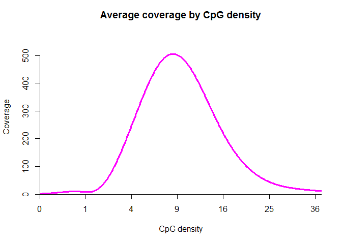

```r
{
    cat("Highest coverage is observed at CpG density of", qcmean(qc$avg.coverage.by.density)^2);
    plot(qc$avg.coverage.by.density)
}
```